# Natural Language Processing – Exercises

Jędrzej Wydra

15th June 2022

# Exercises and Answers

1. **Change `text_data_2` into a vector containing just word “article” and respective number in each element (using function `str_extract()`), then randomly change order of elements. Finally, order output vector using function `str_order()`. `text_data_2` is avaliable in csv file `exercise1`.**

Proposed answer:

```r
library(readr)
library(stringr)
exercise1 <- read.csv("exercise1")$x
extract <- str_extract(string = exercise1, pattern = "Article \\d")
random_order <- extract[sample(1:length(extract), length(extract))]
indexes <- str_order(random_order)
random_order[indexes]
```

```
## [1] "Article 1" "Article 2" "Article 3" "Article 4" "Article 5"
```

2. **Change `text_data_2` into a vector containing just word “article” and respective number in each element (using function `str_remove_all()`), then randomly change order of elements. Finally, order output vector using function `str_sort()`. `text_data_2` is avaliable in csv file `exercise1`.**

Proposed answer:

```r
library(readr)
library(stringr)
exercise1 <- read.csv("exercise1")$x
remove1 <- str_remove_all(string = exercise1, pattern = "\n")
remove2 <- str_remove_all(string = remove1, pattern = "(?<=(Article \\d)).{1,}")
random_order <- remove2[sample(1:length(remove2), length(remove2))]
str_sort(random_order)
```

```
## [1] "Article 1" "Article 2" "Article 3" "Article 4" "Article 5"
```

3. **Download table of current members of the United Nations from [these website](https://en.wikipedia.org/wiki/Member_states_of_the_United_Nations) and remove last column. From the first column remove notes (i.e. strings “[note 1]”, “[note 2]” and so on).**

Proposed answer:

```r
library(rvest)
library(stringr)
library(dplyr)
url <- "https://en.wikipedia.org/wiki/Member_states_of_the_United_Nations"
url %>%
  read_html() %>%
  html_node(xpath='//*[@id="mw-content-text"]/div[1]/table[2]') %>%
  html_table(fill=TRUE) -> table
table <- table[,-3]
table$`Member state` <- str_remove(string = table$`Member state`, pattern = "\\[note \\d\\]")
table
```

```
## # A tibble: 193 × 2
##    `Member state`      `Date of admission`
##    <chr>               <chr>
##  1 Afghanistan         19 November 1946
##  2 Albania             14 December 1955
##  3 Algeria             8 October 1962
##  4 Andorra             28 July 1993
##  5 Angola              1 December 1976
##  6 Antigua and Barbuda 11 November 1981
##  7 Argentina           24 October 1945
##  8 Armenia             2 March 1992
##  9 Australia           1 November 1945
## 10 Austria             14 December 1955
## # … with 183 more rows
```

4. **Using `eurlex` package download document with CELEX number 32021R2282, examine term frequency and plot the results as wordcloud. Plot 72 the most frequent words.**

Proposed answer:

```r
library(eurlex)
library(textstem)
library(tidytext)
library(wordcloud2)
library(dplyr)

elx_make_query(resource_type = "regulation",
               directory = "16") %>%
  elx_run_query() -> dataset

dataset <- dataset[match("32021R2282", dataset$celex),]

legal.act <- elx_fetch_data(dataset$work,
                            type = "text",
                            language_1 = "en")

legal.act <- data.frame(text = legal.act)

legal.act %>%
  unnest_tokens(word, text, token = "ngrams", n = 1) %>%
  anti_join(stop_words) %>%
  mutate(word = lemmatize_words(word)) -> legal.act

legal.act$word <- ifelse(str_remove_all(legal.act$word, "\\d") == "",
                         NA,
                         str_remove_all(legal.act$word,"\\d"))

legal.act <- na.omit(legal.act)

legal.act %>%
  group_by(word) %>%
  summarise(count = n()) %>%
  arrange(desc(count)) %>%
  slice(1:72) -> legal.act.frequency

wordcloud2(legal.act.frequency)
```

[interactive chart not shown]

5. **Using `eurlex` package download legal acts specified in csv file `exercise5`. Then examine what these documents are about and plot the results, but plot just six the most important words.** Hint: directory is 1607.

Proposed answer:

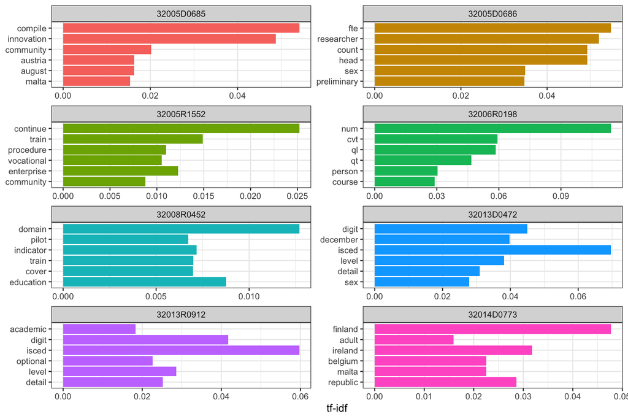

```r
library(readr)
library(eurlex)
library(tidytext)
library(stringr)
library(ggplot2)
library(textstem)
library(dplyr)

exercise5 <- read.csv("exercise5")$x

elx_make_query(resource_type = "any",
               directory = "1607") %>%
  elx_run_query() -> dataset

dataset <- dataset[match(exercise5, dataset$celex),]

legal.acts <- data.frame(CELEX=dataset$celex,
                         text=unlist(lapply(dataset$work,elx_fetch_data,
                                            language_1 = "en",
                                            type = "text")))

legal.acts$text <- str_remove_all(legal.acts$text,"\\d")

legal.acts %>%
  unnest_tokens(word, text) %>%
  anti_join(stop_words) %>%
  mutate(word = lemmatize_words(word)) %>%
  group_by(CELEX, word)%>%
  summarise(n = n())%>%
  arrange(desc(n)) -> act.word

act.word %>%
  bind_tf_idf(word, CELEX, n) -> act.word.2

act.word.2 %>%
  arrange(desc(tf_idf)) %>%
  mutate(word = factor(word, levels = rev(unique(word)))) %>%
  group_by(CELEX) %>%
  slice(1:6) %>%
  ungroup() %>%
  ggplot(aes(word, tf_idf, fill = CELEX)) +
  geom_col(show.legend = FALSE) +
  labs(x = NULL, y = "tf-idf") +
  facet_wrap(~CELEX, ncol = 2, scales = "free") +
  coord_flip()+
  theme_bw()
```

6. **Group documents from csv file `exercise6`. There should be six groups: “Regulations”, “Decisions”, “Recommendations”, “Opinions”, “Resolutions”, “Other documents”. Create data frame where the first column is CELEX number and the second column is group name.**

Proposed answer:

Hello, Buddy! If you thought that you should have use LDA, then sorry, you were wrong. I’m little mean. The answer is nothing more than pattern recognition. ;)

Import data to R environment.

```r
dataset <- read.csv("exercise6")$x
dataset <- str_remove(string = dataset, pattern = "CELEX number: ")
uniques <- !duplicated(str_sub(dataset, start = 6L, end = 6L))
coding <- str_sub(dataset, start = 6L, end = 6L)
unique_codes <- coding[uniques]
```

Here you can find information about coding in CELEX numbers

```r
library(rvest)
library(stringr)
library(dplyr)
url <- "https://eur-lex.europa.eu/content/tools/TableOfSectors/types_of_documents_in_eurlex.html"
url %>%
  read_html() %>%
  html_node(xpath='//*[@id="content"]/div/div/div/div[3]/table') %>%
  html_table(fill=TRUE) -> table
codes <- table[table$X2 %in% unique_codes,]
codes <- codes[,-1]
codes$X3 <- str_remove(string = codes$X3, pattern = " \\(with or without addressee\\)")
codes$X3 <- str_remove(string = codes$X3, pattern = " published in OJ C")
names(codes) <- c("code", "object")

codes
```

```
## # A tibble: 6 × 2
##   code  object
##   <chr> <chr>
## 1 R     Regulations
## 2 D     Decisions
## 3 H     Recommendations
## 4 A     Opinions
## 5 G     Resolutions
## 6 Y     Other documents
```

The rest is quite easy.

```r
decoding <- function(x)
{
  return(codes$object[match(x,codes$code)])
}

answer <- data.frame(CELEX = dataset, code = coding)

answer %>%
  mutate(object = decoding(code)) -> answer

answer <- answer[,-2]

answer
```

```
##             CELEX          object
## 1      32021R0101     Regulations
## 2      32021R0100     Regulations
## 3  32017A0608(01)        Opinions
## 4  32015A1205(01)        Opinions
## 5  32015A0228(01)        Opinions
## 6  32014A1122(01)        Opinions
## 7  32010A1222(01)        Opinions
## 8      32010H0635 Recommendations
## 9  32010A0928(01)        Opinions
## 10 32010A0804(01)        Opinions
## 11 32010A0415(01)        Opinions
## 12 32010A0414(01)        Opinions
## 13 32010A0320(01)        Opinions
## 14 32010A0318(01)        Opinions
```

[output cut: 26 more lines]